# Neural Networks and Machine Learning Course Project

## Cornell University - CEEM586

### Leonid Shpaner, 2022-11-19

# Part One

## Load the requisite libraries

```r
pack <- function(lib){
  new.lib <- lib[!(lib %in%
                     installed.packages()[, "Package"])]
  if (length(new.lib))
    install.packages(new.lib, dependencies = TRUE)
  sapply(lib, require, character.only = TRUE)
}

packages <- c('neuralnet', 'corrplot', 'caret', 'caTools', 'ggplot2', 'ggpubr',
              'cowplot', 'h2o', 'lime')
pack(packages)
```

```
## neuralnet  corrplot     caret   caTools   ggplot2    ggpubr   cowplot       h2o
##      TRUE      TRUE      TRUE      TRUE      TRUE      TRUE      TRUE      TRUE
##      lime
##      TRUE
```

```r
getwd() # establish current working directory
```

$$1$$
“C:/Users/lshpaner/Documents/GitHub Repositories/CEEM586_Neural_Networks_and_ML/code”

```r
# set new working directory
working_dir = paste('C:/Users/lshpaner/OneDrive/Cornell University/Coursework/',
                    'CEEM586 - Neural Networks and Machine Learning/', sep='')
setwd(working_dir)
```

```r
# Read in the data
election <- read.csv(paste("https://raw.githubusercontent.com/lshpaner/",
                           "CEEM586_Neural_Networks_and_ML/main/data/",
                           "ElectionData.csv", sep=""), row.names = 1,
                     header = TRUE,
                     stringsAsFactors = FALSE)
```

## Preprocessing

```r
# remove index column to better adapt to machine learning format
rownames(election) <- NULL
head(election) #inspect the df
```

```
##   fips US.regions PacificCoast MountainsPlains South Midwest Northeast
## 1 1001          3            0               0     1       0         0
## 2 1003          3            0               0     1       0         0
## 3 1005          3            0               0     1       0         0
## 4 1007          3            0               0     1       0         0
## 5 1009          3            0               0     1       0         0
## 6 1011          3            0               0     1       0         0
##   Population PercentFemale PercentWhite PercentAfricanAmerican
## 1  41435.460          51.4         77.9                   18.7
## 2 155686.358          51.2         87.1                    9.6
## 3  21186.956          46.6         50.2                   47.6
## 4  17779.740          45.9         76.3                   22.1
## 5  44097.316          50.5         96.0                    1.8
## 6   8460.504          45.3         26.9                   70.1
##   PercentNativeAmerican PercentAsian PercentHawaianPI PercentTwoorMore
```

[output cut: 34 more lines]

```r
# remove Clinton from the dataframe
election_new <- election; election_new$Clinton <- NULL

head(election_new) # reinspect the new df
```

```
##   fips US.regions PacificCoast MountainsPlains South Midwest Northeast
## 1 1001          3            0               0     1       0         0
## 2 1003          3            0               0     1       0         0
## 3 1005          3            0               0     1       0         0
## 4 1007          3            0               0     1       0         0
## 5 1009          3            0               0     1       0         0
## 6 1011          3            0               0     1       0         0
##   Population PercentFemale PercentWhite PercentAfricanAmerican
## 1  41435.460          51.4         77.9                   18.7
## 2 155686.358          51.2         87.1                    9.6
## 3  21186.956          46.6         50.2                   47.6
## 4  17779.740          45.9         76.3                   22.1
## 5  44097.316          50.5         96.0                    1.8
## 6   8460.504          45.3         26.9                   70.1
##   PercentNativeAmerican PercentAsian PercentHawaianPI PercentTwoorMore
```

[output cut: 27 more lines]

```r
str(election_new[1,]) # inspect the structure of the df
```

```
## 'data.frame':    1 obs. of  27 variables:
##  $ fips                      : int 1001
##  $ US.regions                : int 3
##  $ PacificCoast              : int 0
##  $ MountainsPlains           : int 0
##  $ South                     : int 1
##  $ Midwest                   : int 0
##  $ Northeast                 : int 0
##  $ Population                : num 41435
##  $ PercentFemale             : num 51.4
##  $ PercentWhite              : num 77.9
##  $ PercentAfricanAmerican    : num 18.7
##  $ PercentNativeAmerican     : num 0.5
##  $ PercentAsian              : num 1.1
##  $ PercentHawaianPI          : num 0.1
##  $ PercentTwoorMore          : num 1.8
##  $ PercentHispanic           : num 2.7
##  $ Percent.White.Not.Hispanic: num 75.6
##  $ Percent.foreign.born      : num 1.6
##  $ PercentLangDiffEnglish    : num 3.5
##  $ Bachlorsorhigher          : num 20.9
##  $ HighSchoolGrad            : num 64.7
##  $ HomeOwnership             : num 76.8
##  $ PersonsPerHouse           : num 2.71
##  $ IncomeperCapita           : int 24571
##  $ PercentBelowPoverty       : num 12.1
##  $ PopPerSqMile              : num 91.8
##  $ Trump                     : num 0.734
```

```r
cat("Dimensions of dataset:", dim(election_new), # dimensions of dataset
    "\n", "There are", sum(is.na(election_new)),
    "'NA' values in the entire dataset.")
```

```
## Dimensions of dataset: 3143 27
##  There are 0 'NA' values in the entire dataset.
```

## Exploratory Data Analysis (EDA)

### Correlation Matrix

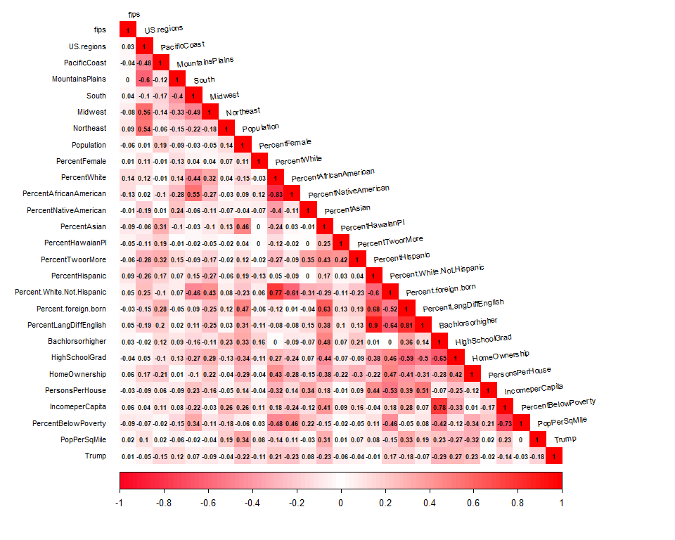

```r
# create a correl. matrix between all variables
frame_trump <- cor(election_new)

corrplot(frame_trump,
         mar = c(0, 0, 0, 0),
         method="color",
         col=colorRampPalette(c("#FC0320",
                                "white",
                                "#FF0000"))(100),
         addCoef.col = "black", tl.col="black",
         tl.srt=6, tl.offset = 1,
         number.cex=0.55, tl.cex = 0.7, type='lower')
```

```r
# assign variable to count how many highly correlated
# variables there exist based on 0.75 threshold
highCorr <- findCorrelation(frame_trump, cutoff = 0.75)

# find correlated names
highCorr_names <- findCorrelation(frame_trump, cutoff = 0.75,
                                  names = TRUE)

cat("There are",
    length(highCorr_names),
    "highly correlated predictors. \n \n")
```

There are 5 highly correlated predictors.

```r
highCorr_names
```

$$1$$
“Percent.White.Not.Hispanic” “Percent.foreign.born”
$$3$$
“PercentLangDiffEnglish” “PercentWhite”
$$5$$
“Bachlorsorhigher”

### Correlation

Various economic indicators may shed light on election results. These important variable relationships are examined in the ensuing scatter plot diagrams. Plot A demonstrates that there exists a strong negative correlation (*r* = -0.98) between Clinton’s fraction of Votes to that of Trump’s. In Plot B, as income per capita decreases, the percent below poverty increases, so there exists a strong negative relationship (*r* = -0.73) between the two. Plot C shows that there is a weak (almost moderate) relationship (*r* = -0.34) between home ownership and percent below poverty; so, as the percent below poverty increases, home ownership begins to decrease. Lastly, persons per house shares a low correlation (*r* = 0.21) with percent below poverty, so it is difficult to compare the two.

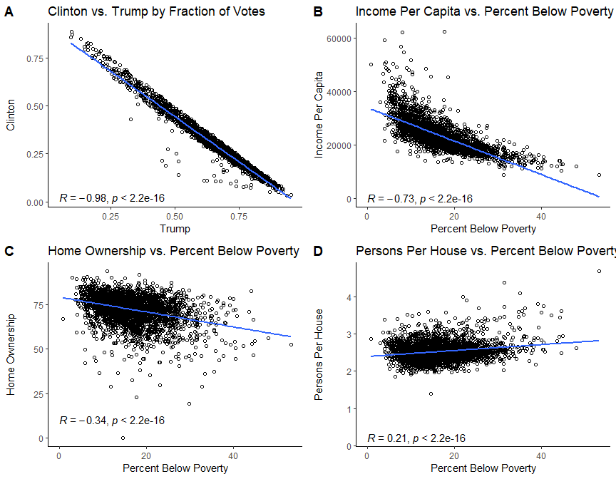

```r
x1 = election$Trump; y1 = election$Clinton
corrplot1 <- ggplot(election, aes(x = x1, y = y1)) +
                    ggtitle("Clinton vs. Trump by Fraction of Votes") +
                    xlab('Trump') + ylab('Clinton') +
                    geom_point(pch=1) +
                    geom_smooth(method="lm", se=FALSE) +
                    theme_classic() +
                    # Add correlation coefficient
                    stat_cor(method = "pearson", label.x = 0.05, label.y = 0.02)

x2 = election$PercentBelowPoverty; y2 = election$IncomeperCapita
corrplot2 <- ggplot(election, aes(x = x2, y = y2)) +
                    ggtitle("Income Per Capita vs. Percent Below Poverty") +
                    xlab('Percent Below Poverty') + ylab('Income Per Capita') +
                    geom_point(pch=1) +
                    geom_smooth(method="lm", se=FALSE) +
                    theme_classic() +
                    # Add correlation coefficient
                    stat_cor(method = "pearson", label.x = 0.15, label.y = 0.20)

x3 = election$PercentBelowPoverty; y3 = election$HomeOwnership
corrplot3 <- ggplot(election, aes(x = x3, y = y3)) +
                    ggtitle("Home Ownership vs. Percent Below Poverty") +
                    xlab('Percent Below Poverty') + ylab('Home Ownership') +
                    geom_point(pch=1) +
                    geom_smooth(method="lm", se=FALSE) +
                    theme_classic() +
                    # Add correlation coefficient
                    stat_cor(method = "pearson", label.x = 0.15, label.y = 10)

x4 = election$PercentBelowPoverty; y4 = election$PersonsPerHouse
corrplot4 <- ggplot(election, aes(x = x4, y = y4)) +
                    ggtitle("Persons Per House vs. Percent Below Poverty") +
                    xlab('Percent Below Poverty') + ylab('Persons Per House') +
                    geom_point(pch=1) +
                    geom_smooth(method="lm", se=FALSE) +
                    theme_classic() +
                    # Add correlation coefficient
                    stat_cor(method = "pearson", label.x = 0.15, label.y = 0.20)

plot_grid(corrplot1, corrplot2, corrplot3, corrplot4, labels="AUTO", ncol = 2,
          align = "v")
```

```r
# remove highly correlated predictors
election_new$Percent.White.Not.Hispanic <- NULL
election_new$Percent.foreign.born <- NULL
election_new$PercentLangDiffEnglish <- NULL
election_new$PercentWhite <- NULL
election_new$Bachlorsorhigher <- NULL
```

## Partition The Data

The dataset is partitioned using a 70/30 train/test split

```r
set.seed(222) # set seed for reproducibility
#Use 70% of dataset as training set and remaining 30% as testing set
sample <- sample(c(TRUE, FALSE), nrow(election_new), replace=TRUE,
                 prob=c(0.7,0.3))
train  <- election_new[sample, ] # training set
test   <- election_new[!sample, ] # test set

cat("\n Training Dimensions:",dim(train),
    "\n Testing Dimensions:", dim(test), "\n",
    "\n Training Dimensions Percentage:", round(nrow(train)/
                                                nrow(election_new),2),
    "\n Testing Dimensions Percentage:", round(nrow(test)/
                                               nrow(election_new),2))
```

```
##
##  Training Dimensions: 2186 22
##  Testing Dimensions: 957 22
##
##  Training Dimensions Percentage: 0.7
##  Testing Dimensions Percentage: 0.3
```

### Preprocessing via Normalization

```r
# Create a function to normalize the data by scaling it between 0 and 1
normalize <- function(x) {return ((x-min(x))/(max(x)-min(x)))}

# Use the normalize function to normalize each column of train and test
# This creates a new dataframe by applying the normalize function to each row
# of the dataset ‘frame’
maxmindtrain <- as.data.frame(lapply(train, normalize))
maxmindtest <- as.data.frame(lapply(test, normalize))
```

```r
# Define input and output variables to create the training data data frame
input_train <- train[c(1:22)]
input_test <- test[c(1:22)]
output_train <- train$Trump # training output
output_test <- test$Trump # validation output
trainingdata <- cbind(input_train, output_train)
testdata <- cbind(input_test, output_test)
```

## Generalized Linear Model

```r
set.seed(222)
lm.fit <- glm(Trump~., data=trainingdata)
summary(lm.fit)
```

```
##
## Call:
## glm(formula = Trump ~ ., data = trainingdata)
##
## Deviance Residuals:
##        Min          1Q      Median          3Q         Max
## -9.992e-16  -3.331e-16  -1.110e-16   2.220e-16   1.166e-15
##
## Coefficients: (2 not defined because of singularities)
##                          Estimate Std. Error    t value Pr(>|t|)
## (Intercept)             1.112e-17  3.416e-16  3.300e-02 0.974031
## fips                    1.419e-21  5.556e-22  2.555e+00 0.010698 *
## US.regions             -1.938e-16  3.539e-17 -5.477e+00 4.83e-08 ***
## PacificCoast           -4.894e-16  1.230e-16 -3.980e+00 7.11e-05 ***
## MountainsPlains        -5.678e-16  8.248e-17 -6.885e+00 7.57e-12 ***
## South                  -5.426e-16  5.116e-17 -1.061e+01  < 2e-16 ***
## Midwest                        NA         NA         NA       NA
## Northeast                      NA         NA         NA       NA
## Population              5.198e-23  4.696e-23  1.107e+00 0.268464
## PercentFemale           1.303e-17  3.783e-18  3.444e+00 0.000583 ***
## PercentAfricanAmerican  1.064e-17  8.595e-19  1.238e+01  < 2e-16 ***
## PercentNativeAmerican   3.026e-19  1.416e-18  2.140e-01 0.830823
## PercentAsian            7.091e-18  4.264e-18  1.663e+00 0.096505 .
## PercentHawaianPI        4.762e-18  8.261e-18  5.760e-01 0.564363
## PercentTwoorMore       -5.311e-18  7.205e-18 -7.370e-01 0.461098
## PercentHispanic        -4.935e-19  8.324e-19 -5.930e-01 0.553334
## HighSchoolGrad         -1.252e-17  1.774e-18 -7.054e+00 2.32e-12 ***
## HomeOwnership          -3.491e-18  1.367e-18 -2.554e+00 0.010711 *
## PersonsPerHouse        -3.482e-17  4.271e-17 -8.150e-01 0.415082
## IncomeperCapita        -1.327e-21  3.025e-21 -4.380e-01 0.661080
## PercentBelowPoverty    -6.857e-18  2.609e-18 -2.629e+00 0.008636 **
## PopPerSqMile            1.119e-20  8.475e-21  1.320e+00 0.187033
## output_train            1.000e+00  5.303e-17  1.886e+16  < 2e-16 ***
## ---
## Signif. codes:  0 '***' 0.001 '**' 0.01 '*' 0.05 '.' 0.1 ' ' 1
##
## (Dispersion parameter for gaussian family taken to be 1.43169e-31)
##
##     Null deviance: 6.6136e+01  on 2185  degrees of freedom
## Residual deviance: 3.0996e-28  on 2165  degrees of freedom
## AIC: -149026
##
## Number of Fisher Scoring iterations: 1
```

## Simple Neural Network Model

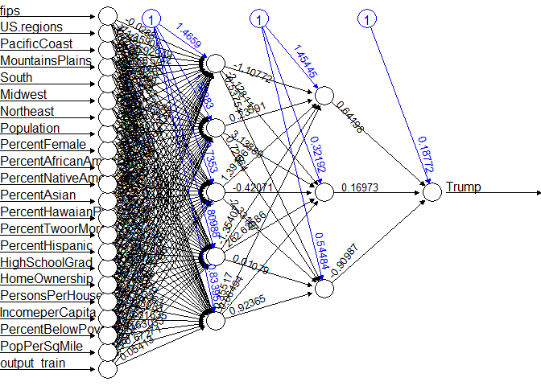

```r
set.seed(222)
n_train <- names(trainingdata)
n_test <- names(testdata)

f_train <- as.formula(paste("Trump ~", paste(n_train[!n_train %in% "Trump"],
                                             collapse = " + ")))
f_test <- as.formula(paste("Trump ~", paste(n_test[!n_test %in% "Trump"],
                                            collapse = " + ")))

# 2 hidden layers with 5 and 3 neurons, respectively
nn_train <- neuralnet(f_train,data=trainingdata,hidden=c(5,3),linear.output=T)
nn_test <- neuralnet(f_test,data=testdata,hidden=c(5,3), linear.output=T)
plot(nn_train, rep = "best") # plot the neural network - training data
```

## Predict on Training Data and Test Data

```r
set.seed(222)
# Compute fitted values from the training data
predictions_train <- predict(nn_train, newdata=trainingdata)

# Test the neural networks out of sample performance
predictions_test <- predict(nn_test, newdata=testdata)
# Compute mean absolute error between true and fitted values
# we are wrong on average by this many fraction of votes

train_mae = mean(abs(predictions_train-output_train))
test_mae = mean(abs(predictions_test-output_test))

cat('\n', 'Train MAE:', train_mae,
    '\n', 'Test MAE:', test_mae,
    '\n', 'Difference in MAE Between Train and Validation Set:',
     train_mae - test_mae)
```

```
##
##  Train MAE: 0.1362437
##  Test MAE: 0.1285449
##  Difference in MAE Between Train and Validation Set: 0.007698762
```

# Part Two

## Initialize H2o

```r
h2o.init()
```

```
##  Connection successful!
##
## R is connected to the H2O cluster:
##     H2O cluster uptime:         1 days 6 hours
##     H2O cluster timezone:       America/Los_Angeles
##     H2O data parsing timezone:  UTC
##     H2O cluster version:        3.38.0.1
##     H2O cluster version age:    2 months and 5 days
##     H2O cluster name:           H2O_started_from_R_lshpaner_orw759
##     H2O cluster total nodes:    1
##     H2O cluster total memory:   3.60 GB
##     H2O cluster total cores:    8
##     H2O cluster allowed cores:  8
##     H2O cluster healthy:        TRUE
##     H2O Connection ip:          localhost
##     H2O Connection port:        54321
##     H2O Connection proxy:       NA
##     H2O Internal Security:      FALSE
##     R Version:                  R version 4.2.2 (2022-10-31 ucrt)
```

## Read in the data

```r
housing <- read.csv(paste("https://raw.githubusercontent.com/lshpaner/",
                          "CEEM586_Neural_Networks_and_ML/main/data/",
                          "DC_PropertieResidentialunder1mill.csv", sep=""),
                    header=TRUE)
head(housing[,1:10]) # examine first five columns of data
```

```
##      X.1 BATHRM HF_BATHRM BATHROOMS AC1IsYes NUM_UNITS ROOMS BEDRM  EYB STORIES
## 1 105692      3         1       3.5        1         1     8     3 2018       2
## 2 105499      2         0       2.0        0         1     6     2 1947       2
## 3  85758      2         0       2.0        0         2    10     4 1955       2
## 4  87741      1         0       1.0        0         1     5     2 1945       2
## 5 102505      1         0       1.0        0         1     4     2 1953       2
## 6  90764      1         0       1.0        0         1     4     1 1947       1
```

```r
str(housing[1,]) # examine structure of dataframe
```

```
## 'data.frame':    1 obs. of  108 variables:
##  $ X.1                       : int 105692
##  $ BATHRM                    : int 3
##  $ HF_BATHRM                 : int 1
##  $ BATHROOMS                 : num 3.5
##  $ AC1IsYes                  : int 1
##  $ NUM_UNITS                 : int 1
##  $ ROOMS                     : int 8
##  $ BEDRM                     : int 3
##  $ EYB                       : int 2018
##  $ STORIES                   : num 2
##  $ YearSold                  : int 2018
##  $ Month                     : int 1
##  $ Winter                    : int 1
##  $ Spring                    : int 0
```

[output cut: 86 more lines]

## Preprocessing

```r
# remove non-numeric variables s.t. amendable to ML modeling
housing$CENSUS_BLOCK <- NULL
housing$BATHRM <- NULL # unrounded expression of bathrooms
housing$CNDTN <- NULL
housing$EXTWALL <- NULL
housing$ROOF <- NULL
housing$INTWALL <- NULL
housing$ASSESSMENT_SUBNBHD <- NULL
# contains 53 levels (already as variables/columns)
housing$ASSESSMENT_NBHD <- NULL
housing$SQUARE <- NULL
housing$QUADRANT <- NULL
# remove logPrice since PRICE is the target, and we do not
# need to linearize it
housing$logPrice <- NULL
housing$X <- NULL; housing$Y <- NULL # GPS coordiantes (x, y) --> not necessary
```

```r
# supply names of columns that have 0 variance
names(housing[, sapply(housing, function(v) var(v, na.rm=TRUE)==0)])
```

```
## [1] "Single"                     "Residential_0.Condo_1"
## [3] "Kalorama"                   "Woodley"
## [5] "MassachusettsAvenueHeights"
```

```r
# exclude zero variance columns
housing <- housing[,sapply(housing, function(v) var(v, na.rm=TRUE)!=0)]
# dimensions of dataset
cat(" Dimensions of dataset:", dim(housing),
    "\n", "There are", sum(is.na(housing)),
    "'NA' values in the entire dataset.")
```

```
##  Dimensions of dataset: 10617 90
##  There are 180 'NA' values in the entire dataset.
```

```r
# assign variable to count how many highly correlated
# variables there exist based on 0.75 threshold
highCorr_names <- findCorrelation(cor(housing, use="pairwise.complete.obs"),
cutoff = 0.75, names = TRUE)

highCorr <- findCorrelation(cor(housing), cutoff = 0.75)
cat(" There are", length(highCorr_names),
    "highly correlated predictors."); highCorr_names
```

```
##  There are 4 highly correlated predictors.

## [1] "NW"        "Ward6"     "Multi"     "NUM_UNITS"
```

```r
# remove highly correlated predictors
housing$NW <- NULL
housing$Ward6 <- NULL
housing$Multi <- NULL
housing$NUM_UNITS <- NULL
# independent variables
X_var <- colnames(housing); X_var <- list(colnames(housing))
# remove response variable[-16] and index[-1] from list
X_var <- X_var[[1]][-15]; X_var <- X_var[-1]; X_var
```

```
##  [1] "HF_BATHRM"           "BATHROOMS"           "AC1IsYes"
##  [4] "ROOMS"               "BEDRM"               "EYB"
##  [7] "STORIES"             "YearSold"            "Month"
## [10] "Winter"              "Spring"              "Summer"
## [13] "PRICE"               "RowInside"           "RowEnd"
## [16] "SemiDetached"        "TownEnd"             "TownInside"
## [19] "GradeLowerBetter"    "KITCHENS"            "FIREPLACES"
## [22] "USECODE"             "LANDAREA"            "CongressHeights"
## [25] "Deanwood"            "RandleHeights"       "FortDupontPark"
## [28] "MichiganPark"        "MarshallHeights"     "ColumbiaHeights"
## [31] "Brookland"           "Trinidad"            "Hillcrest"
## [34] "Burleith"            "Anacostia"           "LilyPonds"
## [37] "BarryFarms"          "Petworth"            "Woodridge"
## [40] "OldCity1"            "Brentwood"           "Eckington"
## [43] "MtPleasant"          "FortLincoln"         "RiggsPark"
## [46] "StreetHeights16th"   "OldCity2"            "TakomaPark"
## [49] "Brightwood"          "Chillum"             "CapitolHill"
## [52] "LedroitPark"         "ChevyChase"          "ShepherdHeights"
## [55] "Georgetown"          "AmericanUniversity"  "FoggyBottom"
## [58] "Kent"                "WesleyHeights"       "Palisades"
## [61] "GloverPark"          "Crestwood"           "ClevelandPark"
## [64] "ColonialVillage"     "SouthwestWaterfront" "Foxhall"
## [67] "NorthClevelandPark"  "Hawthorne"           "SpringValley"
## [70] "Wakefield"           "Centraltri1"         "Berkley"
## [73] "Garfield"            "ForestHills"         "ObservatoryCircle"
## [76] "CENSUS_TRACT"        "Ward"                "Ward2"
## [79] "Ward3"               "Ward4"               "Ward5"
## [82] "Ward7"               "NE"                  "SW"
```

## Partitioning The Data

```r
# dataset is partitioned using a 70/30 train_test split as follows:
set.seed(222) # make this example reproducible
seventy_percent = 0.70*nrow(housing) # what is 70% of length of dataframe?
ind <- sample(1:nrow(housing), seventy_percent)
train_data <- as.h2o(housing[ind,]) # create training set as h2o data frame
test_data <- as.h2o(housing[-ind,]) # create test set as h2o data frame
```

```r
cat(" Training Dimensions:", dim(train_data),
    "\n Testing Dimensions:", dim(test_data),
    "\n Training Percentage:", round(nrow(train_data)/nrow(housing),2),
    "\n Testing Percentage:", round(nrow(test_data)/nrow(housing), 2))
```

```
##  Training Dimensions: 7431 86
##  Testing Dimensions: 3186 86
##  Training Percentage: 0.7
##  Testing Percentage: 0.3
```

## Estimate The Deep Neural Network

```r
dl_DC_Properties1 <- h2o.deeplearning(y="PRICE", x=c(X_var),
                                      training_frame=train_data,
                                      validation_frame=test_data,
                                      activation="Tanh",
                                      epochs=1000, hidden=c(4,4),
                                      standardize=TRUE,
                                      l1=0.0001, l2=0.001,
                                      adaptive_rate=TRUE,
                                      variable_importances=TRUE,
                                      nfolds=3, reproducible=TRUE,
                                      seed=222)
```

## Plot and Model Summary

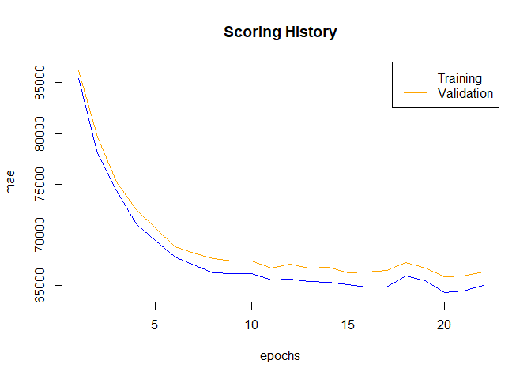

```r
plot(dl_DC_Properties1, metric='mae') # loss plotted throughout training
```

```r
summary(dl_DC_Properties1) # Print model summary information
```

```
## Model Details:
## ==============
##
## H2ORegressionModel: deeplearning
## Model Key:  DeepLearning_model_R_1669239665923_175
## Status of Neuron Layers: predicting PRICE, regression, gaussian distribution, Quadratic loss, 361 weights/biases, 25.1 KB, 163,460 training samples, mini-batch size 1
##   layer units   type dropout       l1       l2 mean_rate rate_rms momentum
## 1     1    83  Input  0.00 %       NA       NA        NA       NA       NA
## 2     2     4   Tanh  0.00 % 0.000100 0.001000  0.006463 0.017503 0.000000
## 3     3     4   Tanh  0.00 % 0.000100 0.001000  0.002768 0.001816 0.000000
## 4     4     1 Linear      NA 0.000100 0.001000  0.001201 0.000268 0.000000
##   mean_weight weight_rms mean_bias bias_rms
## 1          NA         NA        NA       NA
## 2   -0.016761   0.112974 -0.062022 0.055470
## 3   -0.106086   0.360285 -0.018518 0.222929
## 4    0.171316   0.572101  0.043931 0.000000
##
## H2ORegressionMetrics: deeplearning
## ** Reported on training data. **
## ** Metrics reported on full training frame **
##
## MSE:  7427231127
## RMSE:  86181.39
## MAE:  65021.91
## RMSLE:  0.1709592
## Mean Residual Deviance :  7427231127
##
##
## H2ORegressionMetrics: deeplearning
## ** Reported on validation data. **
## ** Metrics reported on full validation frame **
##
## MSE:  7853304605
## RMSE:  88618.87
## MAE:  66306.82
## RMSLE:  0.1721573
## Mean Residual Deviance :  7853304605
##
##
## H2ORegressionMetrics: deeplearning
```

[output cut: 75 more lines]

```
##   variable relative_importance scaled_importance percentage
## 1     Ward            1.000000          1.000000   0.047456
## 2 OldCity1            0.997149          0.997149   0.047321
## 3    Ward5            0.940307          0.940307   0.044623
## 4       NE            0.737750          0.737750   0.035011
## 5    Ward3            0.648867          0.648867   0.030793
##
## ---
##        variable relative_importance scaled_importance percentage
## 78      TownEnd            0.005639          0.005639   0.000268
## 79      Berkley            0.005054          0.005054   0.000240
## 80     Garfield            0.004678          0.004678   0.000222
## 81 SpringValley            0.004343          0.004343   0.000206
## 82      Foxhall            0.004144          0.004144   0.000197
## 83  Centraltri1            0.004132          0.004132   0.000196
```

## Variable Importance

The plot below shows the top ten variables in order of importance.

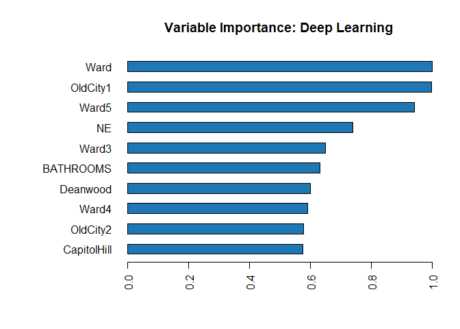

```r
h2o.varimp_plot(dl_DC_Properties1, 10) # plot the first 10 important variables
```

```r
# Retrieve the variable importance
varimp <- h2o.varimp(dl_DC_Properties1)
top_10 <- varimp[1:10,] # for data exploration
top_20 <- varimp[1:20,] # top 20 variables for subsequent modeling
top20_var <- top_20$variable
print(top_10) # print the top 10 variables and their respective importance
```

```
## Variable Importances:
##       variable relative_importance scaled_importance percentage
## 1         Ward            1.000000          1.000000   0.047456
## 2     OldCity1            0.997149          0.997149   0.047321
## 3        Ward5            0.940307          0.940307   0.044623
## 4           NE            0.737750          0.737750   0.035011
## 5        Ward3            0.648867          0.648867   0.030793
## 6    BATHROOMS            0.630164          0.630164   0.029905
## 7     Deanwood            0.600314          0.600314   0.028488
## 8        Ward4            0.591374          0.591374   0.028064
## 9     OldCity2            0.577693          0.577693   0.027415
## 10 CapitolHill            0.574072          0.574072   0.027243
```

## Additional Exploratory Data Analysis (EDA)

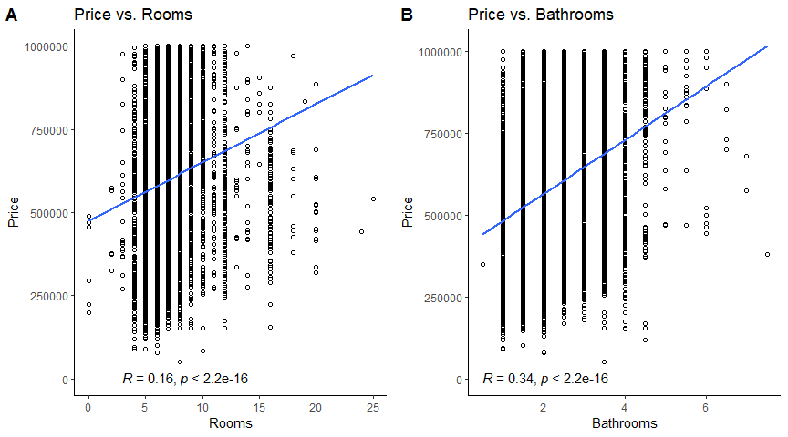

```r
# plot CENSUS-TRACT VS. PRICE
x5 = housing$ROOMS; y5 = housing$PRICE
corrplot5 <- ggplot(housing, aes(x = x5, y = y5)) +
                    ggtitle("Price vs. Rooms") +
                    xlab('Rooms') + ylab('Price') +
                    geom_point(pch=1) +
                    geom_smooth(method="lm", se=FALSE) +
                    theme_classic() +
                    # Add correlation coefficient
                    stat_cor(method = "pearson", label.x = 3, label.y = 30)

# plot BATHROOMS VS. PRICE
x6 = housing$BATHROOM; y6 = housing$PRICE
corrplot6 <- ggplot(housing, aes(x = x6, y = y6)) +
                    ggtitle("Price vs. Bathrooms") +
                    xlab('Bathrooms') +
                    ylab('Price') +
                    geom_point(pch=1) +
                    geom_smooth(method="lm", se=FALSE) +
                    theme_classic() +
                    # Add correlation coefficient
                    stat_cor(method = "pearson", label.x = 0.5, label.y = 30)

plot_grid(corrplot5, corrplot6, labels="AUTO", ncol = 2, align = "v")
```

### Correlation Matrix

Since we have already determined and omitted the highly correlated predictors from the main dataframe, this is just another sanity check to confirm that no more of them exist.

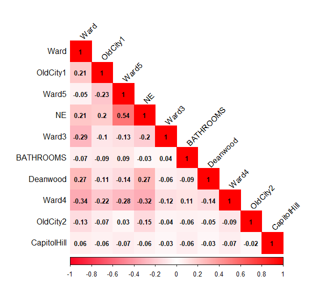

```r
# create list from top 10 variables
list <- c(top_10['variable'])

# subset top 10 variables into new df
top_ten_housing <- housing[c(top_10[,'variable'])]

# assign correlation function call to variable
cor_top_ten_housing <- cor(top_ten_housing,
                           use="pairwise.complete.obs")

# plot the correlation table (matrix)
corrplot(cor_top_ten_housing,
         method="color",
         col=colorRampPalette(c("#FC0320",
                                "white",
                                "#FF0000"))(200),
                              addCoef.col = "black",
                              tl.col="black",
                              tl.srt=45,
                              type="lower",
                              number.cex = 0.8)
```

## Re-estimate The Deep Neural Network

```r
dl_DC_Properties2 <- h2o.deeplearning(y="PRICE", x=c(top20_var),
                                      training_frame=train_data,
                                      validation_frame=test_data,
                                      activation="Tanh",
                                      # hidden_layer, node
                                      epochs=1000, hidden=c(2,2),
                                      standardize=TRUE, l1=0.0001,
                                      l2=0.01, adaptive_rate=TRUE,
                                      variable_importances=TRUE,
                                      nfolds=3, reproducible=TRUE,
                                      seed=222)
```

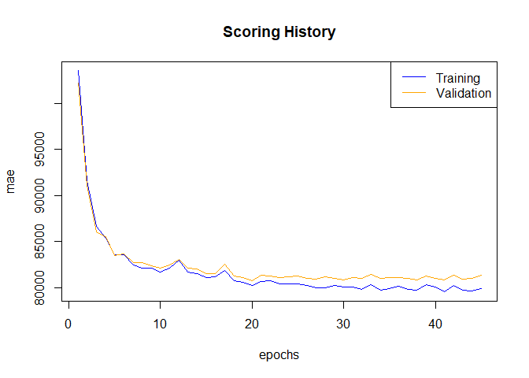

```r
plot(dl_DC_Properties2, metric='mae') # training and test loss plotted
```

```r
summary(dl_DC_Properties2) # print out model summary information and statistics
```

```
## Model Details:
## ==============
##
## H2ORegressionModel: deeplearning
## Model Key:  DeepLearning_model_R_1669239665923_176
## Status of Neuron Layers: predicting PRICE, regression, gaussian distribution, Quadratic loss, 51 weights/biases, 8.6 KB, 334,350 training samples, mini-batch size 1
##   layer units   type dropout       l1       l2 mean_rate rate_rms momentum
## 1     1    20  Input  0.00 %       NA       NA        NA       NA       NA
## 2     2     2   Tanh  0.00 % 0.000100 0.010000  0.000686 0.000399 0.000000
## 3     3     2   Tanh  0.00 % 0.000100 0.010000  0.000833 0.000008 0.000000
## 4     4     1 Linear      NA 0.000100 0.010000  0.001650 0.000005 0.000000
##   mean_weight weight_rms mean_bias bias_rms
## 1          NA         NA        NA       NA
## 2    0.057244   0.190851 -0.148886 0.275054
## 3   -0.001733   0.607373 -0.013848 0.267461
## 4    0.028742   0.999523  0.069607 0.000000
##
## H2ORegressionMetrics: deeplearning
## ** Reported on training data. **
## ** Metrics reported on full training frame **
##
## MSE:  10655045164
## RMSE:  103223.3
## MAE:  79867.15
## RMSLE:  0.1955951
## Mean Residual Deviance :  10655045164
##
##
## H2ORegressionMetrics: deeplearning
## ** Reported on validation data. **
## ** Metrics reported on full validation frame **
##
## MSE:  11110356183
## RMSE:  105405.7
## MAE:  81295.32
## RMSLE:  0.1959436
## Mean Residual Deviance :  11110356183
##
##
## H2ORegressionMetrics: deeplearning
```

[output cut: 81 more lines]

```
## 6            Ward4            0.322812          0.322812   0.052432
## 7      CapitolHill            0.273834          0.273834   0.044477
## 8            Ward7            0.268182          0.268182   0.043559
## 9         LANDAREA            0.250221          0.250221   0.040641
## 10        OldCity2            0.237900          0.237900   0.038640
## 11 CongressHeights            0.221452          0.221452   0.035969
## 12       RowInside            0.216636          0.216636   0.035187
## 13        Deanwood            0.206530          0.206530   0.033545
## 14          RowEnd            0.198102          0.198102   0.032176
## 15      FIREPLACES            0.194298          0.194298   0.031558
## 16           Ward3            0.185223          0.185223   0.030084
## 17        YearSold            0.178580          0.178580   0.029005
## 18       RiggsPark            0.165993          0.165993   0.026961
## 19       Eckington            0.108953          0.108953   0.017696
## 20           Ward5            0.102287          0.102287   0.016614
```

## Predictions

```r
# Predict outputs on the test set
predictions<-h2o.predict(dl_DC_Properties2, test_data)

# print the predictions
print(predictions)
```

[output not shown]

## LIME Analysis

```r
# Create data set for analysis with LIME
# Pick 5 indices from the training set
for_lime <- sample(1:nrow(housing[ind,]), 5)
data_for_lime <- housing[for_lime,]
```

## Fit Deep Neural Network

```r
dl_DC_Properties3 <- h2o.deeplearning(y="PRICE", x=c(top20_var),
                                      training_frame=train_data,
                                      validation_frame=test_data,
                                      activation="Tanh",
                                      # hidden_layer, node
                                      epochs=1000, hidden=c(2,2),
                                      standardize=TRUE, l1=0.0001,
                                      l2=0.015, adaptive_rate=TRUE,
                                      variable_importances=TRUE,
                                      reproducible = TRUE,
                                      seed=222)
```

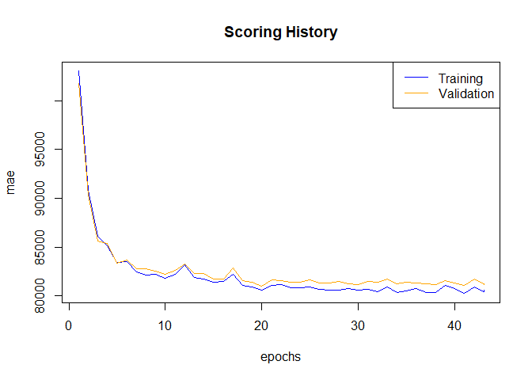

```r
plot(dl_DC_Properties3, metric='mae') # training and test loss plotted
```

```r
summary(dl_DC_Properties3) # print out model summary information and statistics
```

```
## Model Details:
## ==============
##
## H2ORegressionModel: deeplearning
## Model Key:  DeepLearning_model_R_1669239665923_177
## Status of Neuron Layers: predicting PRICE, regression, gaussian distribution, Quadratic loss, 51 weights/biases, 8.6 KB, 319,490 training samples, mini-batch size 1
##   layer units   type dropout       l1       l2 mean_rate rate_rms momentum
## 1     1    20  Input  0.00 %       NA       NA        NA       NA       NA
## 2     2     2   Tanh  0.00 % 0.000100 0.015000  0.000654 0.000377 0.000000
## 3     3     2   Tanh  0.00 % 0.000100 0.015000  0.000859 0.000025 0.000000
## 4     4     1 Linear      NA 0.000100 0.015000  0.001490 0.000005 0.000000
##   mean_weight weight_rms mean_bias bias_rms
## 1          NA         NA        NA       NA
## 2    0.051512   0.176232 -0.134090 0.161091
## 3   -0.008659   0.573687 -0.008806 0.185086
## 4    0.031357   0.971660  0.042558 0.000000
##
## H2ORegressionMetrics: deeplearning
## ** Reported on training data. **
## ** Metrics reported on full training frame **
##
## MSE:  10864716184
## RMSE:  104233.9
## MAE:  80587.15
## RMSLE:  0.1974277
## Mean Residual Deviance :  10864716184
##
##
## H2ORegressionMetrics: deeplearning
## ** Reported on validation data. **
## ** Metrics reported on full validation frame **
##
## MSE:  11077810850
## RMSE:  105251.2
## MAE:  81200.46
## RMSLE:  0.1954749
## Mean Residual Deviance :  11077810850
##
##
##
```

[output cut: 54 more lines]

```
## 6      CapitolHill            0.337646          0.337646   0.051648
## 7        RowInside            0.323545          0.323545   0.049491
## 8         LANDAREA            0.290953          0.290953   0.044506
## 9         OldCity2            0.289853          0.289853   0.044337
## 10           Ward3            0.265222          0.265222   0.040570
## 11           Ward7            0.255013          0.255013   0.039008
## 12      FIREPLACES            0.248743          0.248743   0.038049
## 13 CongressHeights            0.237316          0.237316   0.036301
## 14           Ward4            0.232625          0.232625   0.035583
## 15        Deanwood            0.201429          0.201429   0.030812
## 16        YearSold            0.200445          0.200445   0.030661
## 17       RiggsPark            0.188013          0.188013   0.028759
## 18          RowEnd            0.173127          0.173127   0.026482
## 19       Eckington            0.130757          0.130757   0.020001
## 20           Ward5            0.078222          0.078222   0.011965
```

```r
# Convert data_for_lime into an h2o data frame
predict_data_for_lime <- as.h2o(data_for_lime)
# Compute predictions with estimated neural network for the lime dataset
predictionsforlime <- h2o.predict(dl_DC_Properties3, predict_data_for_lime)

# Use lime to analyze the predictions
explainer_price <- lime(data_for_lime, dl_DC_Properties3)
explanation <- explain(data_for_lime, explainer_price, n_labels = 2,
                       n_features = 4)
```

```r
print(explanation) # print explanation output
```

```
## # A tibble: 20 × 11
##    model_type case  model_r2 model_int…¹ model…² feature featu…³ featu…⁴ featu…⁵
##    <chr>      <chr>    <dbl>       <dbl>   <dbl> <chr>     <dbl>   <dbl> <chr>
##  1 regression 5009     0.684     517791. 513531. Ward        4    2.11e5 Ward <…
##  2 regression 5009     0.684     517791. 513531. BATHRO…     2.5 -1.13e5 BATHRO…
##  3 regression 5009     0.684     517791. 513531. FIREPL…     0   -7.83e4 FIREPL…
##  4 regression 5009     0.684     517791. 513531. LANDAR…  1658   -2.39e4 LANDAR…
##  5 regression 480      0.710     729583. 304552. Ward        8   -2.09e5 5 < Wa…
##  6 regression 480      0.710     729583. 304552. BATHRO…     1   -1.12e5 BATHRO…
##  7 regression 480      0.710     729583. 304552. FIREPL…     0   -8.24e4 FIREPL…
##  8 regression 480      0.710     729583. 304552. LANDAR…  1541   -2.11e4 LANDAR…
##  9 regression 7067     0.647     430790. 640012. Ward        5    2.07e5 Ward <…
## 10 regression 7067     0.647     430790. 640012. BATHRO…     3.5  9.97e4 3.0 < …
## 11 regression 7067     0.647     430790. 640012. FIREPL…     0   -8.21e4 FIREPL…
## 12 regression 7067     0.647     430790. 640012. LANDAR…  1680   -1.52e4 1658 <…
## 13 regression 5089     0.664     418250. 692433. Ward        5    2.06e5 Ward <…
## 14 regression 5089     0.664     418250. 692433. BATHRO…     3.5  1.00e5 3.0 < …
## 15 regression 5089     0.664     418250. 692433. FIREPL…     0   -7.84e4 FIREPL…
## 16 regression 5089     0.664     418250. 692433. LANDAR…  6200    4.66e4 2926 <…
## 17 regression 4938     0.433     401948. 824680. Ward        4    2.11e5 Ward <…
## 18 regression 4938     0.433     401948. 824680. EYB      1947   -2.16e4 EYB <=…
## 19 regression 4938     0.433     401948. 824680. BATHRO…     3    1.29e4 2.5 < …
## 20 regression 4938     0.433     401948. 824680. YearSo…  2016    2.21e5 2016 <…
## # … with 2 more variables: data <list>, prediction <dbl>, and abbreviated
## #   variable names ¹model_intercept, ²model_prediction, ³feature_value,
## #   ⁴feature_weight, ⁵feature_desc
```